# R Notebook

```r
list.of.packages <- c("printr","Metrics","leaps","MASS","caret",
"gghalfnorm","glmnet","ModelMetrics","ISLR",
"ggplot2","dplyr","faraway","knitr","reshape2")
new.packages <- list.of.packages[!(
list.of.packages %in% installed.packages()[,"Package"])]
if(length(new.packages)) install.packages(new.packages)
```

```r
#Loading Libraies
library(faraway)
library(dplyr)
library(ggplot2)
library(ISLR)
library(knitr)
library(printr)
library(Metrics)
library(leaps)
library(MASS)
library(caret)
library(gghalfnorm)
library(glmnet)
```

Let’s see the distribution of the values from the dataset

```r
#Loading Data
data(happy)
row = dim(happy)[1]
col = dim(happy)[2]
c("1"=0,table(happy$happy))
```

```
 1  2  3  4  5  6  7  8  9 10
 0  1  1  4  5  2  8 14  3  1
```

As you can see there is noboyd in the value 1. Nobody gave the happiness rating as 1 in the observations.

```r
table(happy$sex)
```

```
 0  1
12 27
```

```r
table(happy$love)
```

```
 1  2  3
 3 15 21
```

```r
table(happy$work)
```

```
 1  2  3  4  5
 2  6 10 18  3
```

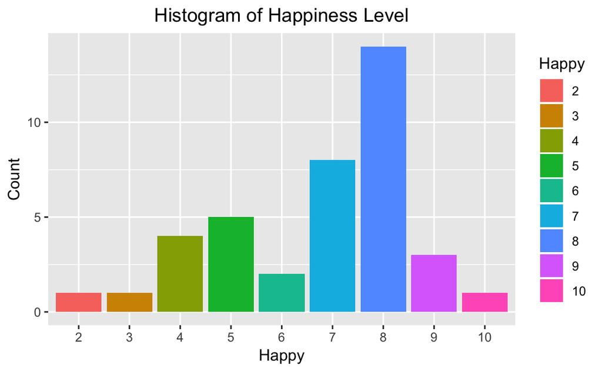

```r
#Histogrram for Happinness
a <- ggplot(happy, aes(x = factor(happy),fill=factor(happy)))
a + geom_bar(aes(fill = factor(happy))) + xlab("Happy")+ylab("Count")+
labs(title = "Histogram of Happiness Level",fill = "Happy") +
theme(plot.title = element_text(hjust=0.5))
```

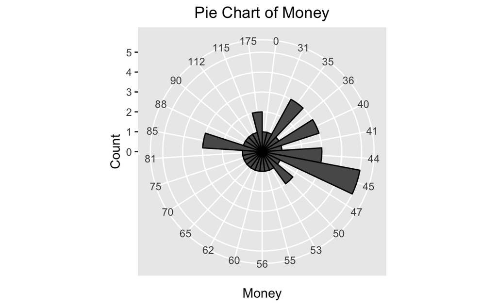

```r
#Pie Chart for money
cxc <- ggplot(happy, aes(x = factor(money))) +
geom_bar(width = 1, colour = "black")
cxc + coord_polar()+ xlab("Money")+ylab("Count")+
labs(title = "Pie Chart of Money") + theme(plot.title = element_text(hjust=0.5))
```

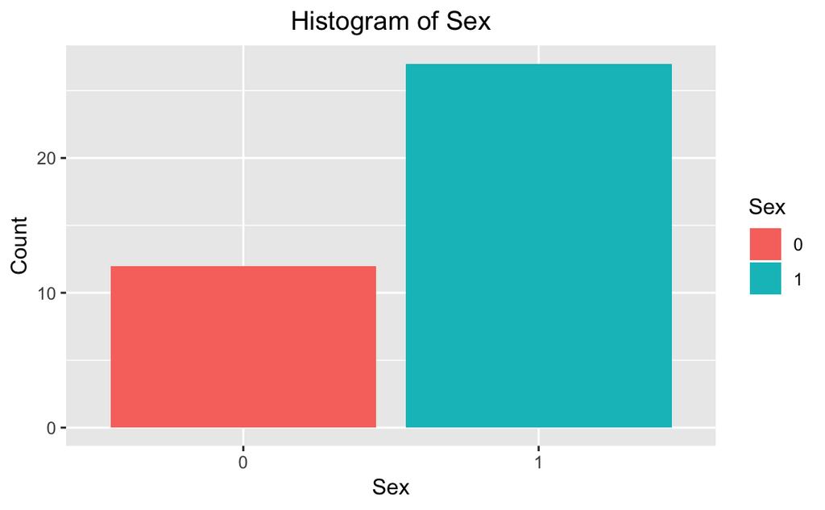

```r
#Histogram for Sex
a <- ggplot(happy, aes(x=factor(sex),fill=factor(sex)))
a + geom_bar(aes(fill = factor(sex))) + xlab("Sex")+
ylab("Count")+labs(title = "Histogram of Sex",fill = "Sex") +
theme(plot.title = element_text(hjust=0.5))
```

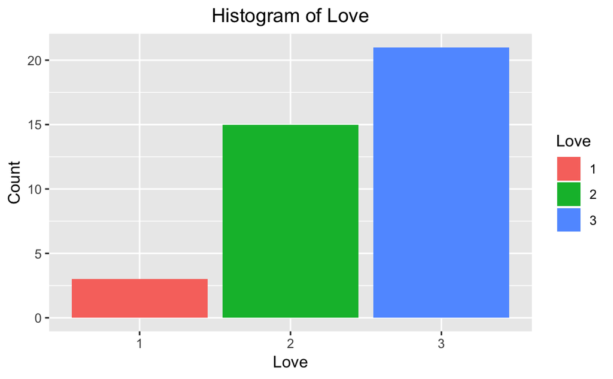

```r
#Histogram for Love
a <- ggplot(happy, aes(x=factor(love),fill=factor(love)))
a + geom_bar(aes(fill = factor(love))) + xlab("Love")+ylab("Count")+
labs(title = "Histogram of Love",fill = "Love") +
theme(plot.title = element_text(hjust=0.5))
```

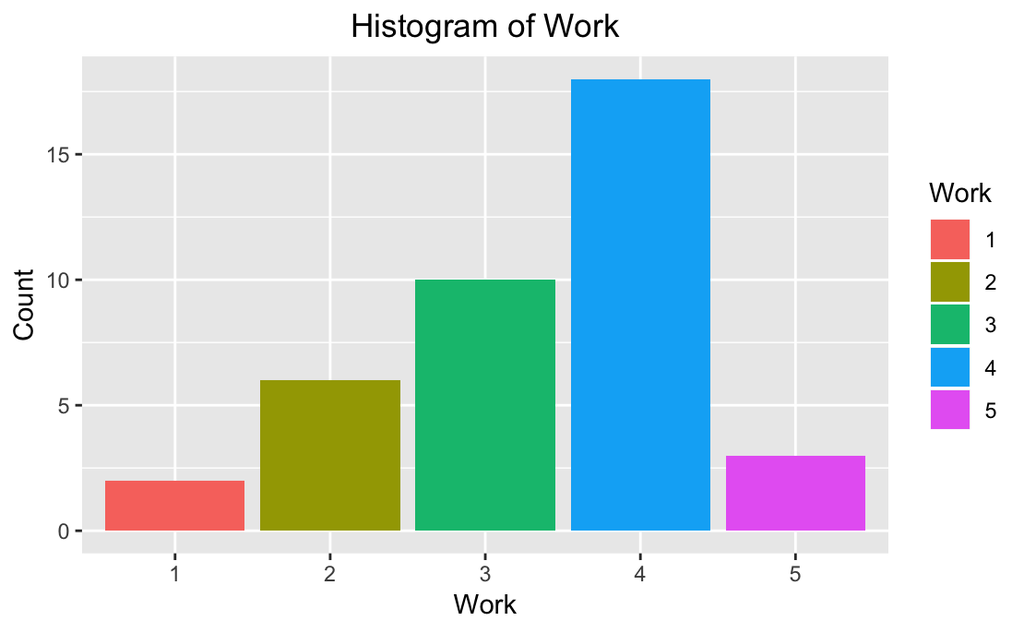

```r
#Histogram for work
a <- ggplot(happy, aes(x=factor(work),fill=factor(work)))
a + geom_bar(aes(fill = factor(work))) + xlab("Work")+ylab("Count")+
labs(title = "Histogram of Work",fill = "Work") +
theme(plot.title = element_text(hjust=0.5))
```

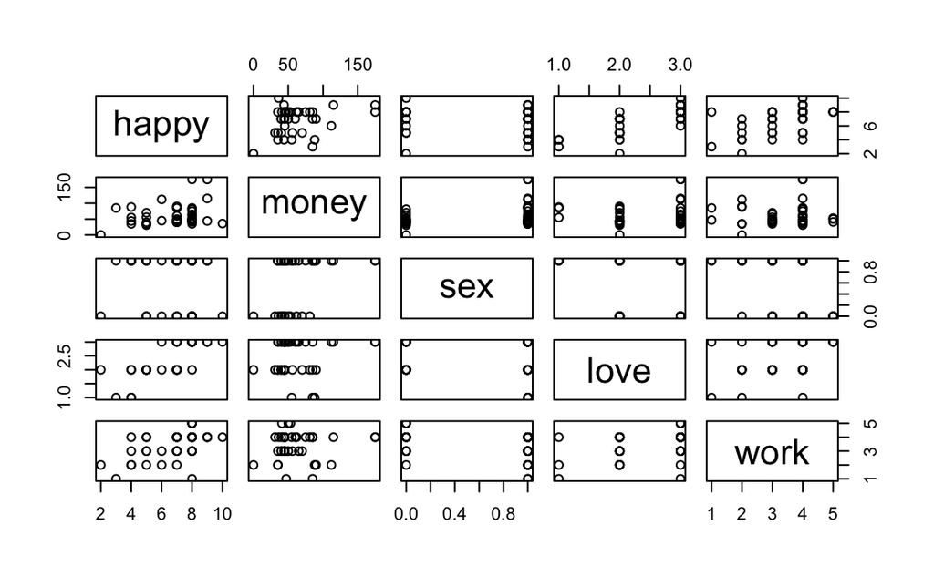

```r
#pairwise scatter plot
pairs(happy)
```

```r
#covariance matrix and VIF
round(cor(happy),3)
```

```
       happy money    sex  love   work
happy  1.000 0.271 -0.033 0.784  0.539
money  0.271 1.000  0.307 0.126  0.068
sex   -0.033 0.307  1.000 0.047 -0.316
love   0.784 0.126  0.047 1.000  0.386
work   0.539 0.068 -0.316 0.386  1.000
```

Seems like sex has no effect on the happiness level from the correlation matrix.

```r
#regression with all terms
all<-lm(happy~.,data=happy) #all coef should be positive
summary(all)
```

```
Call:
lm(formula = happy ~ ., data = happy)

Residuals:
    Min      1Q  Median      3Q     Max
-2.7186 -0.5779 -0.1172  0.6340  2.0651

Coefficients:
             Estimate Std. Error t value Pr(>|t|)
(Intercept) -0.072081   0.852543  -0.085   0.9331
money        0.009578   0.005213   1.837   0.0749 .
sex         -0.149008   0.418525  -0.356   0.7240
love         1.919279   0.295451   6.496 1.97e-07 ***
work         0.476079   0.199389   2.388   0.0227 *
---
Signif. codes:  0 ‘***’ 0.001 ‘**’ 0.01 ‘*’ 0.05 ‘.’ 0.1 ‘ ’ 1

Residual standard error: 1.058 on 34 degrees of freedom
Multiple R-squared:  0.7102,    Adjusted R-squared:  0.6761
F-statistic: 20.83 on 4 and 34 DF,  p-value: 9.364e-09
```

```r
vif(happy)
```

```
   happy    money      sex     love     work
3.450936 1.257565 1.303891 2.740516 1.615127
```

```r
#regression without sex,
nosex<-lm(happy~ money+love+work,data=happy)
summary(nosex)
```

```
Call:
lm(formula = happy ~ money + love + work, data = happy)

Residuals:
     Min       1Q   Median       3Q      Max
-2.62468 -0.57099 -0.08903  0.58675  2.14389

Coefficients:
             Estimate Std. Error t value Pr(>|t|)
(Intercept) -0.185936   0.780372  -0.238   0.8131
money        0.008959   0.004852   1.846   0.0733 .
love         1.901709   0.287644   6.611 1.22e-07 ***
work         0.503602   0.181486   2.775   0.0088 **
---
Signif. codes:  0 ‘***’ 0.001 ‘**’ 0.01 ‘*’ 0.05 ‘.’ 0.1 ‘ ’ 1

Residual standard error: 1.045 on 35 degrees of freedom
Multiple R-squared:  0.7091,    Adjusted R-squared:  0.6842
F-statistic: 28.44 on 3 and 35 DF,  p-value: 1.689e-09
```

```r
anova(nosex,all)
```

```
Analysis of Variance Table

Model 1: happy ~ money + love + work
Model 2: happy ~ money + sex + love + work
  Res.Df    RSS Df Sum of Sq      F Pr(>F)
1     35 38.229
2     34 38.087  1     0.142 0.1268  0.724
```

```r
#subset selection
b <- regsubsets(happy~.,data=happy)
summary(b)
```

```
Subset selection object
Call: regsubsets.formula(happy ~ ., data = happy)
4 Variables  (and intercept)
      Forced in Forced out
money     FALSE      FALSE
sex       FALSE      FALSE
love      FALSE      FALSE
work      FALSE      FALSE
1 subsets of each size up to 4
Selection Algorithm: exhaustive
         money sex love work
1  ( 1 ) " "   " " "*"  " "
2  ( 1 ) " "   " " "*"  "*"
3  ( 1 ) "*"   " " "*"  "*"
4  ( 1 ) "*"   "*" "*"  "*"
```

```r
rs <- summary(b)
```

We select the best model for each size from 1 to 4, and observed that for size $n = 3$, the model without sex is the best model.

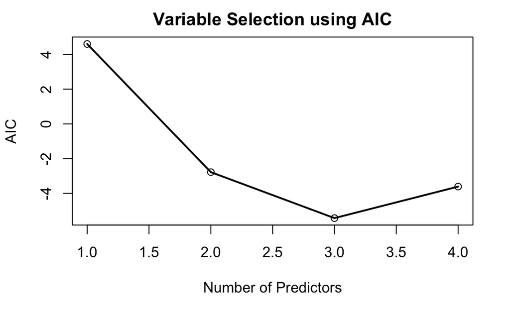

```r
#####Plot AIC
AIC <- 50*log(rs$rss/50) + (2:5)*2
plot(AIC~I(1:4),ylab="AIC",xlab="Number of Predictors",type="l",lwd=2,main = "Variable Selection using AIC")
points(AIC)
```

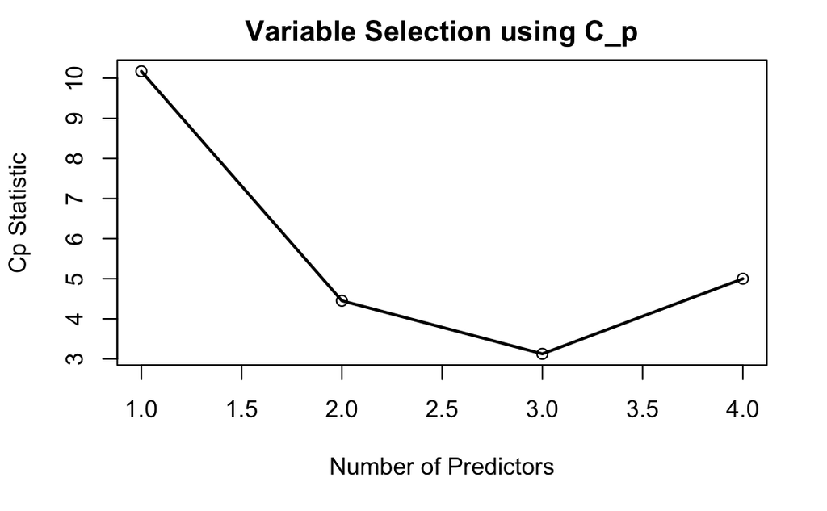

```r
###Plot Cp
plot(1:4,rs$cp,xlab="Number of Predictors",
ylab="Cp Statistic",type="l",lwd=2,
main = "Variable Selection using C_p")
points(1:4,rs$cp)
```

Hence we should remove sex from our model.

```r
#regression without sex,
nosex<-lm(happy~ money+love+work,data=happy)
summary(nosex)
```

```
Call:
lm(formula = happy ~ money + love + work, data = happy)

Residuals:
     Min       1Q   Median       3Q      Max
-2.62468 -0.57099 -0.08903  0.58675  2.14389

Coefficients:
             Estimate Std. Error t value Pr(>|t|)
(Intercept) -0.185936   0.780372  -0.238   0.8131
money        0.008959   0.004852   1.846   0.0733 .
love         1.901709   0.287644   6.611 1.22e-07 ***
work         0.503602   0.181486   2.775   0.0088 **
---
Signif. codes:  0 ‘***’ 0.001 ‘**’ 0.01 ‘*’ 0.05 ‘.’ 0.1 ‘ ’ 1

Residual standard error: 1.045 on 35 degrees of freedom
Multiple R-squared:  0.7091,    Adjusted R-squared:  0.6842
F-statistic: 28.44 on 3 and 35 DF,  p-value: 1.689e-09
```

```r
#regression without intercept and sex
nointsex<-lm(happy~ money+love+work-1,data=happy)
summary(nointsex)
```

```
Call:
lm(formula = happy ~ money + love + work - 1, data = happy)

Residuals:
     Min       1Q   Median       3Q      Max
-2.69584 -0.57051 -0.06483  0.58320  2.15992

Coefficients:
      Estimate Std. Error t value Pr(>|t|)
money 0.008644   0.004608   1.876  0.06879 .
love  1.862795   0.233659   7.972 1.82e-09 ***
work  0.485124   0.161919   2.996  0.00493 **
---
Signif. codes:  0 ‘***’ 0.001 ‘**’ 0.01 ‘*’ 0.05 ‘.’ 0.1 ‘ ’ 1

Residual standard error: 1.031 on 36 degrees of freedom
Multiple R-squared:  0.9799,    Adjusted R-squared:  0.9782
F-statistic:   585 on 3 and 36 DF,  p-value: < 2.2e-16
```

```r
anova(nointsex,nosex)
```

```
Analysis of Variance Table

Model 1: happy ~ money + love + work - 1
Model 2: happy ~ money + love + work
  Res.Df    RSS Df Sum of Sq      F Pr(>F)
1     36 38.291
2     35 38.229  1  0.062009 0.0568 0.8131
```

```r
#regression without int,sex and money
nointsexmoney<-lm(happy~love+work-1,data=happy)
summary(nointsexmoney)
```

```
Call:
lm(formula = happy ~ love + work - 1, data = happy)

Residuals:
    Min      1Q  Median      3Q     Max
-3.0822 -0.6563 -0.1563  0.8437  1.9178

Coefficients:
     Estimate Std. Error t value Pr(>|t|)
love   2.0081     0.2278   8.814 1.27e-10 ***
work   0.5330     0.1652   3.225  0.00263 **
---
Signif. codes:  0 ‘***’ 0.001 ‘**’ 0.01 ‘*’ 0.05 ‘.’ 0.1 ‘ ’ 1

Residual standard error: 1.066 on 37 degrees of freedom
Multiple R-squared:  0.9779,    Adjusted R-squared:  0.9767
F-statistic: 819.9 on 2 and 37 DF,  p-value: < 2.2e-16
```

Removing money gives us a simpler model, but only leads to a small reduction in $R^2$. We proceed by carrying our further investigation and analysis to determine whether or not we should keep money in our model.

```r
#squareroot money
rootmoney<-lm(happy~ sqrt(money)+love+work-1,data=happy)
summary(rootmoney)
```

```
Call:
lm(formula = happy ~ sqrt(money) + love + work - 1, data = happy)

Residuals:
    Min      1Q  Median      3Q     Max
-2.2754 -0.6833 -0.1390  0.5546  2.2670

Coefficients:
            Estimate Std. Error t value Pr(>|t|)
sqrt(money)  0.15263    0.06218   2.455   0.0191 *
love         1.73346    0.24128   7.184 1.88e-08 ***
work         0.40422    0.16369   2.469   0.0184 *
---
Signif. codes:  0 ‘***’ 0.001 ‘**’ 0.01 ‘*’ 0.05 ‘.’ 0.1 ‘ ’ 1

Residual standard error: 1 on 36 degrees of freedom
Multiple R-squared:  0.9811,    Adjusted R-squared:  0.9795
F-statistic: 622.9 on 3 and 36 DF,  p-value: < 2.2e-16
```

```r
AIC(all,nosex,nointsex,nointsexmoney,rootmoney)
```

|  | df | AIC |
| --- | --- | --- |
| all | 6 | 121.7534 |
| nosex | 5 | 119.8985 |
| nointsex | 4 | 117.9617 |
| nointsexmoney | 3 | 119.5990 |
| rootmoney | 4 | 115.5633 |

```r
#prediction
X <- model.matrix(rootmoney)
x_zero<-as.data.frame(apply(X,2,quantile))
x_zero$money<-x_zero$"sqrt(money)"^2
x_zero$"sqrt(money)"<-NULL
betahat <- coef(rootmoney)
muhat<-as.matrix(x_zero)%*%c(as.matrix(betahat))
n <- dim(X)[1]
p<-3
predict(rootmoney,x_zero,interval="prediction",level=0.95)
```

```
          fit        lwr       upr
0%   2.137679 0.07579235  4.199565
25%  5.674415 3.62628012  7.722550
50%  7.896478 5.82109083  9.971864
75%  8.164955 6.10069013 10.229219
100% 9.240514 7.10116518 11.379864
```

Take, as an example, a person with stats in the 25% quantile (with secure relationships, an ok job, and a salary of ($\$42.48 k$). Our model predicts with 95% confidence that this person will have a happiness rating in $(3.62628012, 7.722550)$ This implies that even if a person makes only $\$42k$, there is still a chance that that person is feeling quiet happy, ($happy = 7$), given that he/she is in a secure relationship and has an ok job.

Based on the regression analysis that we have carried out, we have determined that our happiness can be predicted based on our money, love and work, but that our rating of sex in insignificant in making this prediction. The model that removes the intercept and the predictor sex, but takes the square root of money provides the best fit for predictions of happy for the observations given in the dataset.